# Normalizing and Building Dataset

### Rainfall

Mean hourly rainfall and scaled mean hourly rainfall should both be cube root transformed.

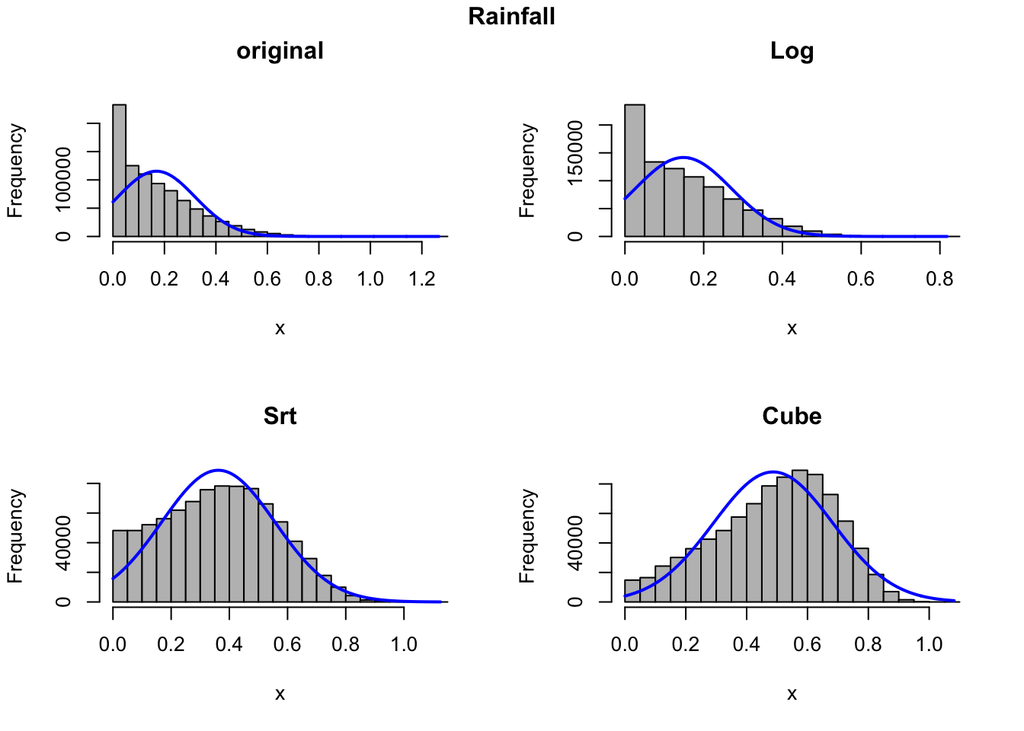

```r
rf <- rf %>%
  group_by(muni.no, cal.month) %>%
  mutate(RFScale = hourlyRainfallMean/max(hourlyRainfallMean))

ExploreTransformations(rf$hourlyRainfallMean, VarName = "Rainfall", shift = TRUE)
```

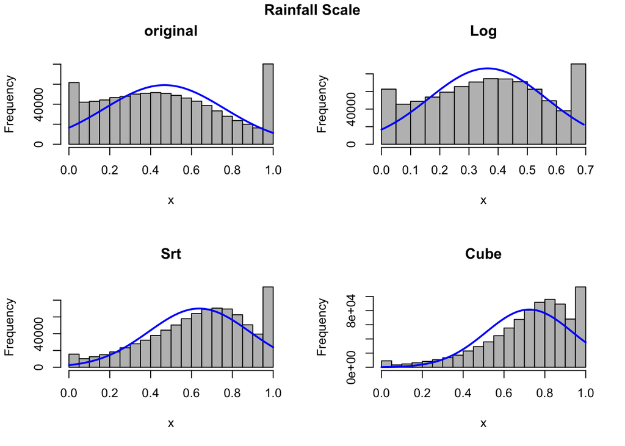

```r
ExploreTransformations(rf$RFScale,VarName = "Rainfall Scale", shift = TRUE)
```

### Fire density

Fire density is ugly despite any transformation. For consistency, we should cube root transform.

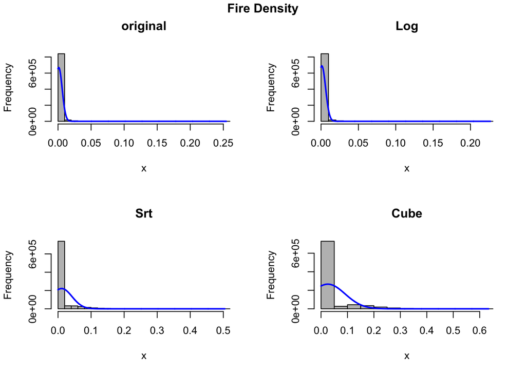

```r
fires <- fires %>%
      group_by(muni.no, cal.month) %>%
   mutate(fireDenScale = ifelse(max(fireDens)==0,0,fireDens/max(fireDens))) %>% #scale fire densities to muni and month
   ungroup()

ExploreTransformations(fires$fireDens,  VarName = "Fire Density", shift = TRUE)
```

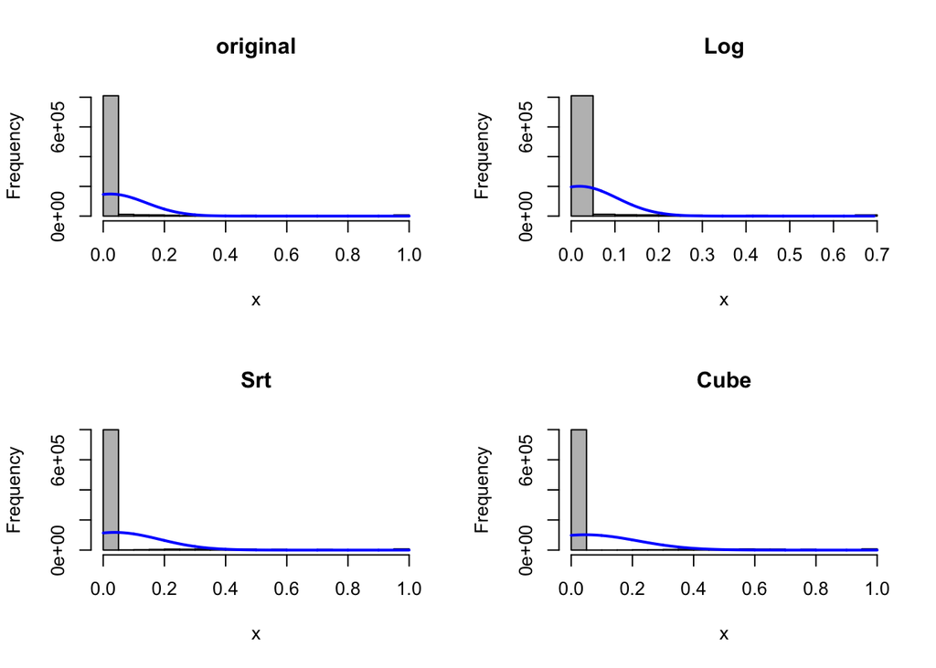

```r
ExploreTransformations(fires$fireDenScale, shift = TRUE)
```

### NDVI

Tranformations aren’t needed for NDVI or NDVI scaled values.

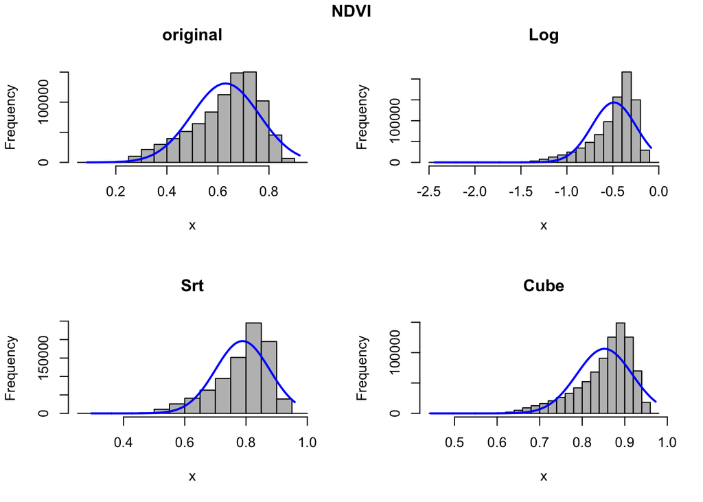

```r
ndvi <- ndvi %>%
  group_by(muni.no, cal.month) %>%
  mutate(NDVIScale = NDVI/max(NDVI)) %>% #scale NDVI to muni and month
  ungroup()

ExploreTransformations(ndvi$NDVI,  VarName = "NDVI")
```

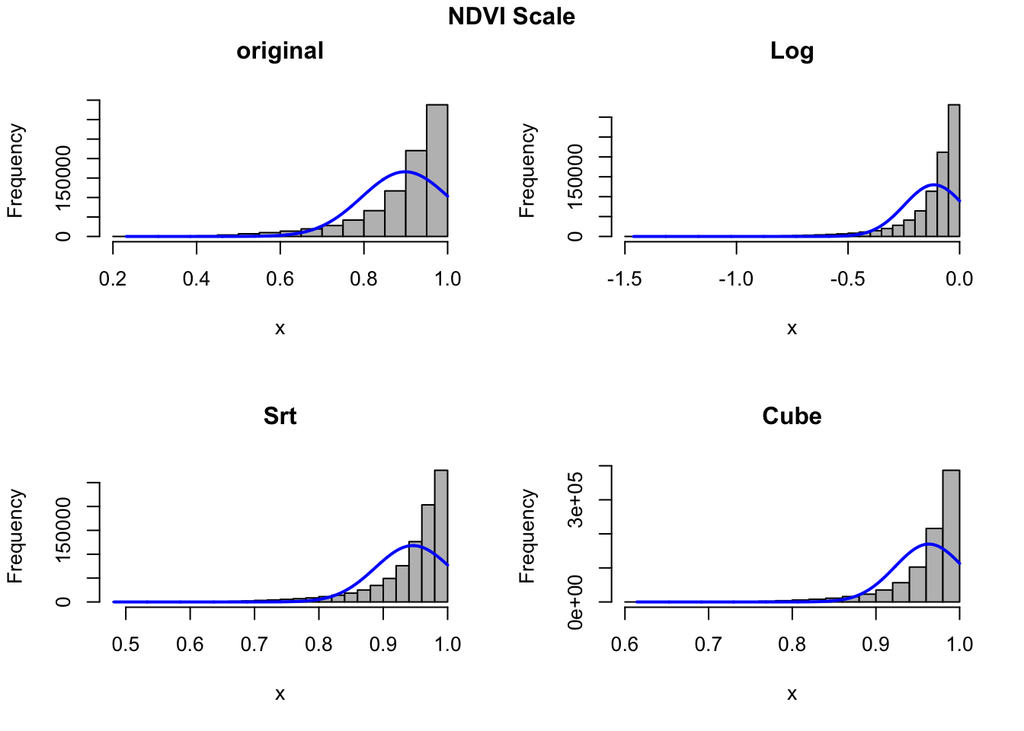

```r
ExploreTransformations(ndvi$NDVIScale, VarName = "NDVI Scale")
```

### Temp

Transformations aren’t needed for temp or temp scale

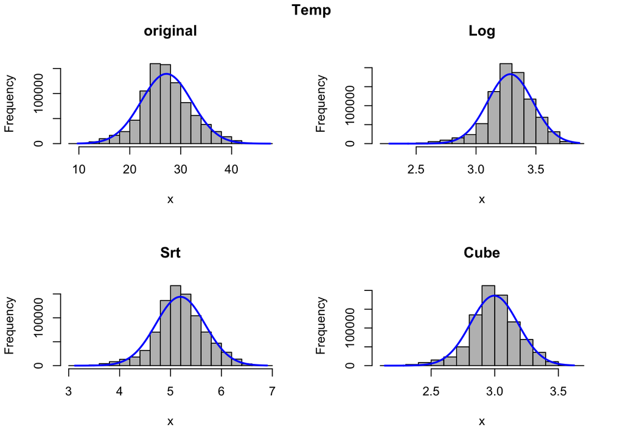

```r
temp <- temp %>%
  group_by(muni.no, cal.month) %>%
  mutate(tempScale = tempMean/max(tempMean)) %>%
  ungroup()

ExploreTransformations(temp$tempMean, VarName = "Temp")
```

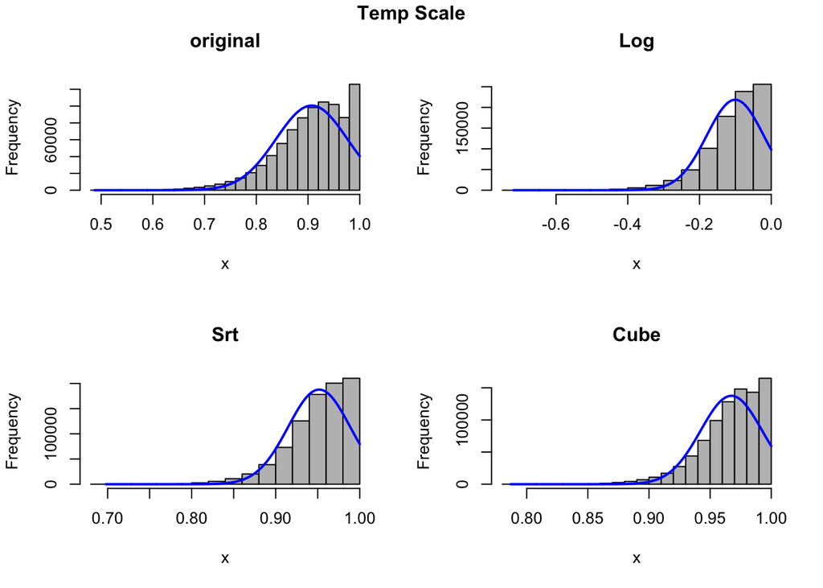

```r
ExploreTransformations(temp$tempScale, VarName = "Temp Scale")
```

### NHP Prop

Primate proportion should be cube root transformed

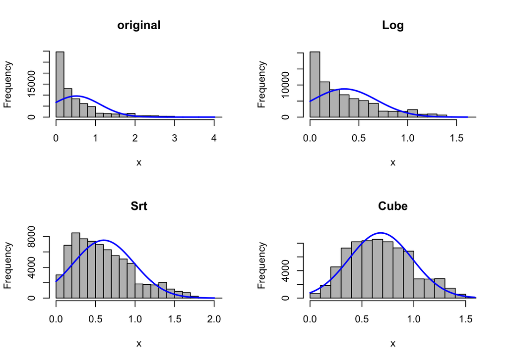

```r
ExploreTransformations(NHPProp$primProp, shift = TRUE)
```

### Species Richness

Species richness should be cube root transformed.

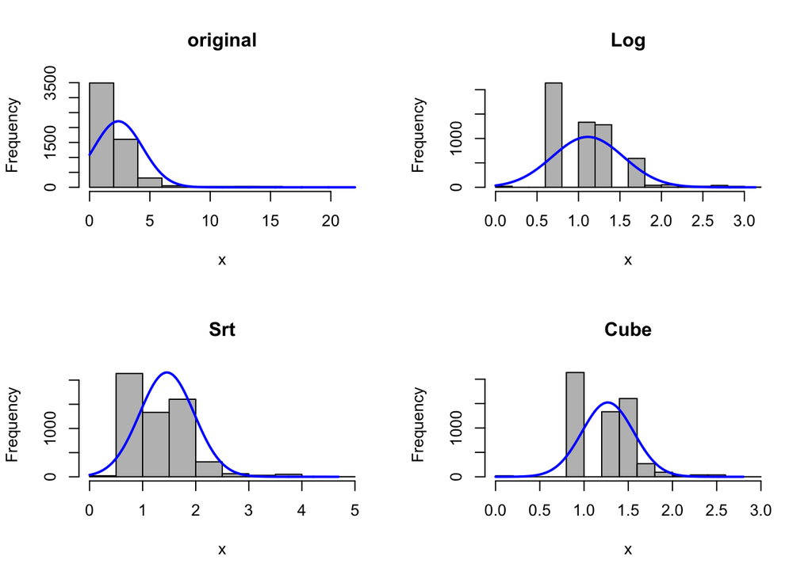

```r
ExploreTransformations(NHPRichness$spRich, shift = TRUE)
```

### Mosi Occurence

Mosi occurance does not need to be transformed.

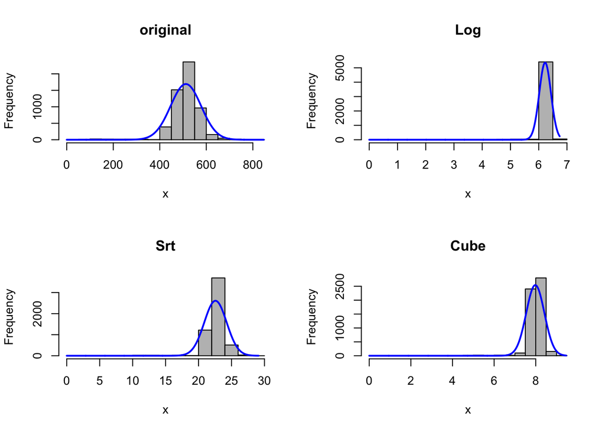

```r
ExploreTransformations(mosi.occurence$vector.prob, shift =TRUE)
```

# Assemble the data

```r
all.enviro <- plyr::join_all(list(ndvi, pop, rf, temp, fires),
                           by=c("muni.no", "month.no"), type="full") %>%
              select(-c(muni, muniArea, area, pop, numFire))

environCovar <- all.enviro %>%
  # scaled variables
    group_by(muni.no, cal.month) %>%
    mutate(tempScale = tempMean/max(tempMean)) %>%
    mutate(ndviScale = NDVI/max(NDVI)) %>%
    mutate(rfScale = hourlyRainfallMean/max(hourlyRainfallMean)) %>%
    mutate(fireScale = ifelse(max(fireDens)==0,0,fireDens/max(fireDens))) %>%
    ungroup() %>%
  # transformations with name changes
    mutate(popLog10 = log10(densitypop)) %>%
    mutate(rf = TranCube(hourlyRainfallMean)) %>%
    mutate(rfScale = TranCube(rfScale)) %>%
    mutate(fire = TranCube(fireDens)) %>%
    mutate(fireScale = TranCube(fireScale)) %>%
  # just name changes
    mutate(ndvi = NDVI) %>%
    mutate(temp = tempMean) %>%
  # drop the extra things
    select(c(muni.no, muni.name, year, cal.month, month.no, rf, rfScale, ndvi, ndviScale, temp, tempScale, popLog10, fire, fireScale))
```

```r
NHPenvironCovar <- NHPRichness %>%
    mutate(spRich = TranCube(spRich)) %>%
    select(-c(muni.name)) %>%
    dplyr::right_join(environCovar, by=c('muni.no'))

NHPenvironCovar <-  NHPProp %>%
    mutate(primProp = TranCube(primProp)) %>%
    select(-c(muni.name)) %>%
    dplyr::right_join(NHPenvironCovar, by=c('muni.no','year'))

allCovar <- mosi.occurence %>%
    mutate(vectorOcc = vector.prob/1000) %>%
    select(-c(vector.prob)) %>%
    dplyr::right_join(NHPenvironCovar, by=c('muni.no'))
```

## YF case data

```r
## YF cases------------------------------
cases <- readRDS("../data_clean/YFcases/YFlong.rds")
 #dimensions: Entries for all muni ONLY if a case reported in any muni that month
cases[is.na(cases)] <- 0 #replace NA with zero

cases <- cases %>%
  filter(year<2014) %>%
  #drop annual totals
  filter(cal.month<=12) %>%
  #drop unknown origin totals %>%
  filter(!grepl("ignorado", muni)) %>%
  mutate(numCase=case) %>%
  mutate(case=ifelse(numCase==0,0,1))


#add in cases
allData <- cases %>%
            select(c(muni.no, month.no, case, numCase)) %>%
            dplyr::right_join(allCovar, by=c('muni.no', 'month.no')) %>%
            mutate(case=ifelse(is.na(case),0,case)) %>% #replace NA with zero
            mutate(numCase=ifelse(is.na(numCase) == TRUE,0,numCase)) #replace NA with zero

saveRDS(allData, "../data_clean/FinalData_Mosi/allData.rds")
# rm(list = ls())
allData <- readRDS("../data_clean/FinalData_Mosi/allData.rds")
```

# Spliting data

Data splits made based on old dataset muni.no and month.no

```r
# Pull in the old data

oldTest <- readRDS("../data_clean/TestingDataSpat2.rds")
oldTestLow <- readRDS("../data_clean/TestingDataLowNHP2.rds")
oldTestHigh <- readRDS("../data_clean/TestingDataHighNHP2.rds")

# pull out rows in common between old data set and new
testing <-  allData %>% semi_join(oldTest, by=c("muni.no", "month.no"))
testingLow <- allData %>% semi_join(oldTestLow, by = c("muni.no", "month.no"))
testingHigh <- allData %>% semi_join(oldTestHigh, by = c("muni.no", "month.no"))

# save testing data
saveRDS(testing, file = "../data_clean/FinalData_Mosi/TestingData.rds")
saveRDS(testingLow, "../data_clean/FinalData_Mosi/TestingDataLowNHP.rds")
saveRDS(testingHigh, "../data_clean/FinalData_Mosi/TestingDataHighNHP.rds")

# Repeat steps for training

# pull in the old data
oldTrain <- readRDS("../data_clean/TrainingDataSpat2.rds")
oldTrainLow <- readRDS("../data_clean/TrainingDataLowNHP2.rds")
oldTrainHigh <- readRDS("../data_clean/TrainingDataHighNHP2.rds")

# pull out rows in common between old data set and new
training <-  allData %>% semi_join(oldTrain, by=c("muni.no", "month.no"))
trainingLow <- allData %>% semi_join(oldTrainLow, by = c("muni.no", "month.no"))
trainingHigh <- allData %>% semi_join(oldTrainHigh, by = c("muni.no", "month.no"))

# Save data with spatial and temporal stratification
#individual training and testing data
saveRDS(training, file="../data_clean/FinalData_Mosi/TrainingData.rds")
saveRDS(trainingLow, "../data_clean/FinalData_Mosi/TrainingDataLowNHP.rds")
saveRDS(trainingHigh, "../data_clean/FinalData_Mosi/TrainingDataHighNHP.rds")
```

```r
CaseSummary = function(x){
  pos <- sum(x$case)
  total <- dim(x)[1]
  bg <- total - pos
  return(c(pos,bg,total))
}

# uick sanity check.
CaseSummary(training)
CaseSummary(trainingLow)
CaseSummary(trainingHigh)


CaseSummary(testing)
CaseSummary(testingLow)
CaseSummary(testingHigh)
```

[output not shown]